# Agrupamiento Jerarquico

Arley Smith

25/4/2021

## Normalizamos los datos tanto numéricos como categóricos

```r
datos_num_scaled <- scale(datos_num,center = TRUE, scale = TRUE)
datos_cat_scaled <- scale(datos_cat,center = TRUE, scale = TRUE)
```

### Calculamos las distancias

```r
D_cat <- dist(datos_cat,method="binary",diag=TRUE)
D_num <- dist(datos_num_scaled,diag=TRUE)
D_Tot <- D_cat + D_num
```

## Realizamos agrupamiento jerárquico para identificar los grupos

### ¿Qué método debemos usar para el agrupamiento?

El método del agrupamiento “hclust” permite especificar la medida de las distancias con las cuales se realizará el agrupamiento, donde:

- *complete* : calcula las diferencias entre las muestras del grupo 1 y el grupo 2 buscando la mayor de estas como la distancia entre los grupos
- *average* : de la misma forma que “complete” calcula las diferencias entre los grupos, pero en lugar de seleccionar la mayor realiza un promedio entre las distancias
- *single* : al ser un método de enlace (busca la forma de unir los conjuntos) busca la diferencia entre las muestras del conjunto 1 y el conjunto 2, buscando la menor distancia para unir dichos conjuntos
- *ward.D* : minimiza la varianza dentro de los conjuntos con el fin de generar los grupos con la menor varianza
- *centroid* : calcula la diferencia entre los centroides de los conjuntos agrupando los de menor distancia

El criterio de selección del método será el método que mejor clasifique el conjunto de datos buscando una distribución proporcional entre la cantidad de elementos de cada conjunto. Para esto, ejecutaremos el agrupamiento para k= 10 (10 grupos) y verificaremos la distribución de las muestras en cada grupo

Adaptado de [@Boehmke]

```r
hc_euclidea_complete <- hclust(d = D_Tot, method = "complete")
hc_euclidea_average  <- hclust(d = D_Tot , method = "average")
hc_euclidea_single  <- hclust(d = D_Tot , method = "single")
hc_euclidea_ward.D  <- hclust(d = D_Tot , method = "ward.D")
hc_euclidea_centroid  <- hclust(d =D_Tot , method = "centroid")
```

Generamos 10 grupos para cada método

```r
grupos_complete <-     table(cutree(hc_euclidea_complete,k=10))
grupos_average  <-    table(cutree(hc_euclidea_average ,k=10))
grupos_single  <-    table(cutree(hc_euclidea_single  ,k=10))
grupos_ward.D  <-    table(cutree(hc_euclidea_ward.D,k=10))
grupos_centroid  <-    table(cutree(hc_euclidea_centroid,k=10))
```

Distribución de los primeros 10 grupos

| Grupos Complete | Grupos Average | Grupos Single | Grupos Ward | Grupos Centroid |
| --- | --- | --- | --- | --- |
| 2219 | 2224 | 2224 | 1291 | 2224 |
| 2 | 1 | 1 | 18 | 1 |
| 4 | 1 | 1 | 151 | 1 |
| 1 | 1 | 1 | 502 | 1 |
| 2 | 1 | 1 | 8 | 1 |
| 1 | 1 | 1 | 91 | 1 |
| 1 | 1 | 1 | 16 | 1 |
| 1 | 1 | 1 | 151 | 1 |
| 1 | 1 | 1 | 4 | 1 |
| 1 | 1 | 1 | 1 | 1 |

Como se puede ver, el método que mejor distribuye la muestra es el método de Ward, una de las posibles razones por las cuales este método distribuye mejor es debido a que la muestra puede tener datos atípicos en alguna de las variables sin embargo, el eliminar o cambiar este tipo de datos puede resultar perjudicial para el agrupamiento, por otro lado tomar un método como average, complete, o single puede llevar a la necesidad de crear muchos grupos dado que cada grupo tiene una muestra única y singular.

[metodo de ward](http://repositorio.lamolina.edu.pe/bitstream/handle/UNALM/3384/dongo-roman-andie-bryan.pdf?sequence=1&isAllowed=y)

```r
cluster_jerar <- hclust(D_Tot,method = "ward.D")
```

### Veamos el dendograma para el agrupamiento

El dendograma es el mapa jerárquico donde se pueden ver todas las ramas y divisiones generadas por el agrupamiento, en esté vemos como a medida que se llega a la parte inferior se van generando más subgrupos que llevan la información cada vez más específica, sin embargo, para lograr una perspectiva global de un ambiente productivo, generalizar grupos según sus características puede llevar a una mejor conclusión y dar facilidades de análisis para la empresa.

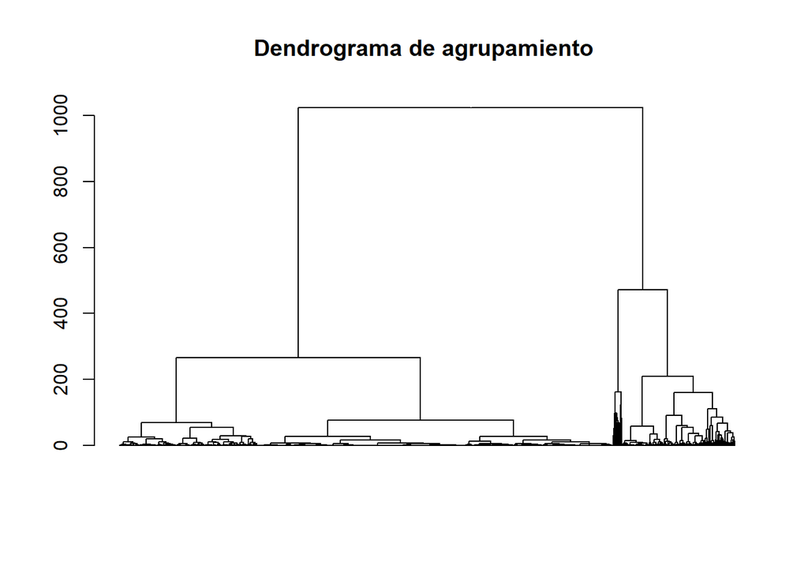

### ¿Qué cantidad de grupos debemos generar en el agrupamiento?

Según el dendogrma vemos que a partir de 5 grupos la información parece volverse más específica lo que genera más subdivisiones que pueden complicar no solo el análisis de cada grupo si no, además, las acciones a tomar para la compañía, junto a esto puede llevar a realizar análisis para grupos que puede ser diferenciados por características muy parecidas entre otros grupos.

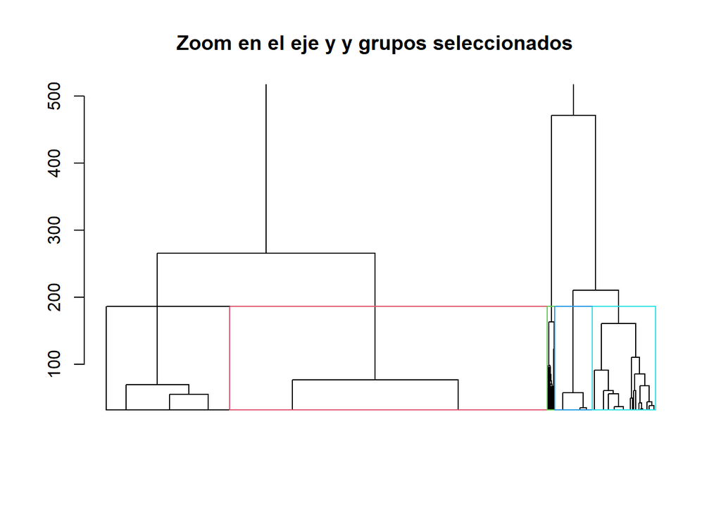

Dado que la cantidad de variables es extensa el análisis y la identificación de las diferencias entre grupos se torna complejo, de esta manera se toma la media de cada variable para cada grupo.

## Análisis de los 5 grupos respecto a sus medias

### ¿Como quedaron distribuidos los grupos?

La distribución de los datos para 5 grupos distribuye los datos de la siguiente forma

- Grupo 1: Contiene el 57.8 % de las muestras
- Grupo 2: Contiene el 1.3 % de las muestras
- Grupo 3: Contiene el 6.76 % de las muestras
- Grupo 4: Contiene el 22.48 % de las muestras
- Grupo 5: Contiene el 11.55 % de las muesrtas

La distribución de los datos parece estar “recostada” a el grupo numero 1 sin embargo el generar más grupos no cambia la distribución del grupo 1 por el contrario son los grupos de menor cantidad de muestras lo que se comienzan a desfragmentar generando grupos de una a cinco empresas. Dado que el objetivo es buscar relaciones en común no es factible el tener grupos de 5 o 1 para una base de 2233 empresas.

Aunque aún no se sabe qué tipo de empresas se encuentran en estos grupos, el grupo numero 1 será un grupo de gran interés pues tiene más de la mitad de las empresas cliente.

Numero de muestras por grupo

| Numeros de grupos | Cantidad de muestras |
| --- | --- |
| 1 | 1291 |
| 2 | 31 |
| 3 | 151 |
| 4 | 502 |
| 5 | 258 |

### Promedio valor medio anual

El promedio de los envíos y salidas anúlales está dominado por el grupo 2, según el agrupamiento estas 31 empresas son las que mas realizan envíos respecto a los demás grupos, además se puede ver que los canales favoritos tanto de entrada y salida son el número 2. Es posible que las empresas del grupo 2 son empresas con un amplio historial como cliente, razón por la cual el promedio de envió a través de los años es mucho mayor que los demás grupos, también es importante mostrar que el grupo 1 en el cual se encuentra la mayoría de las empresas es un grupo que no muestra un promedio alto en comparación a los demás grupos, puede sugerir que hay poca frecuencia en los clientes de este grupo.

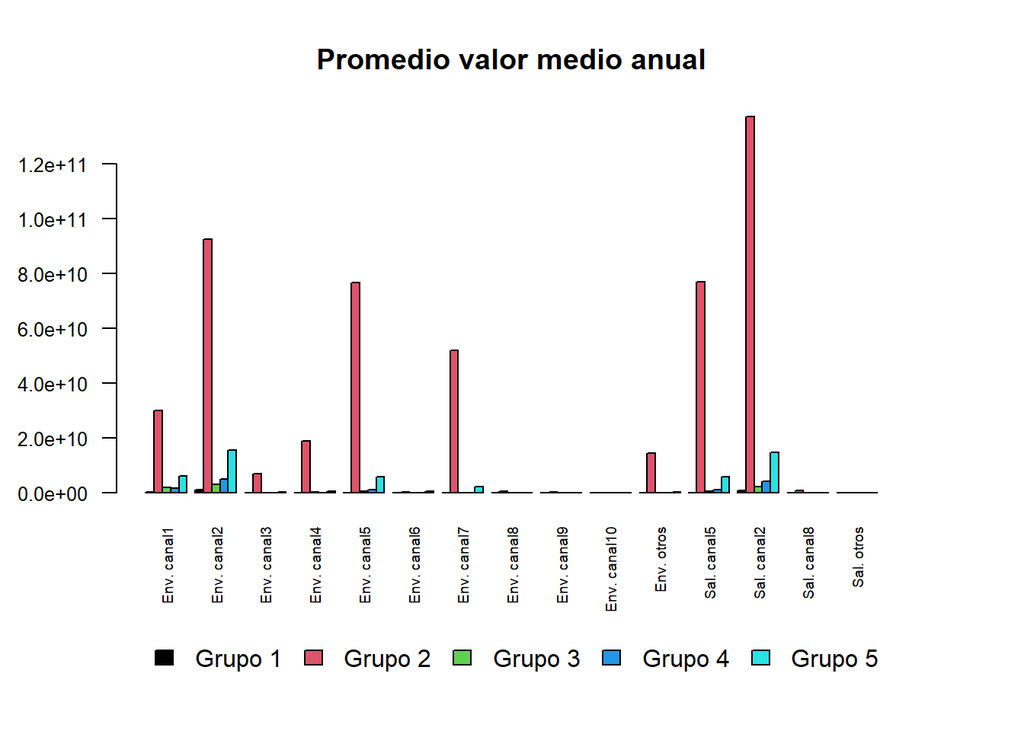

### Total de los canales valor medio anual

Nota: si la empresa en cuestión por ejemplo es un banco, puede sugerir que el canal numero 2 son sucursales físicas ya que se evidencia una relación entre la entrada y salida número 2, por lo cual el canal debe tener la capacidad tanto de entregar como de recibir.

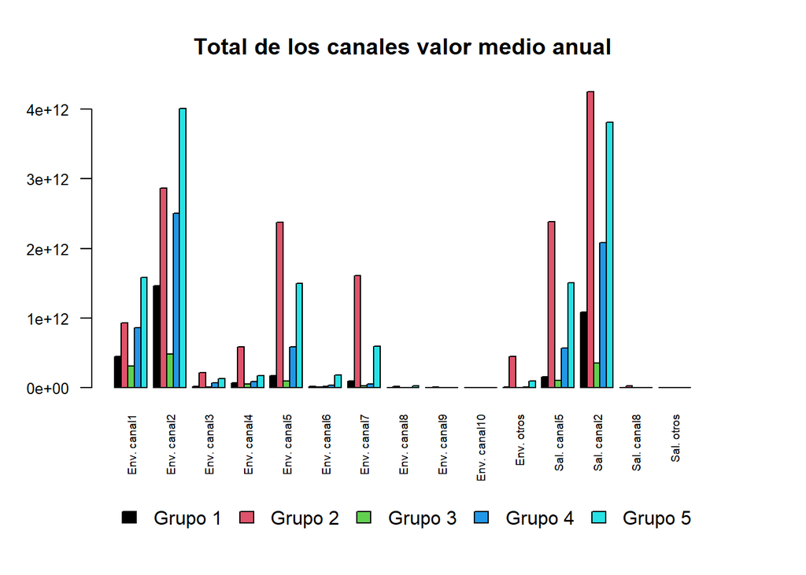

### Promedio de los canales en transacciones mensuales

En comparación a los demás canales el grupo numero 2 tiene un promedio más elevado en el uso de todos los canales en los que se presentó movimiento, una vez más se puede ver que el grupo numero 2 tiene a los clientes que más interacción tienen con la compañía.

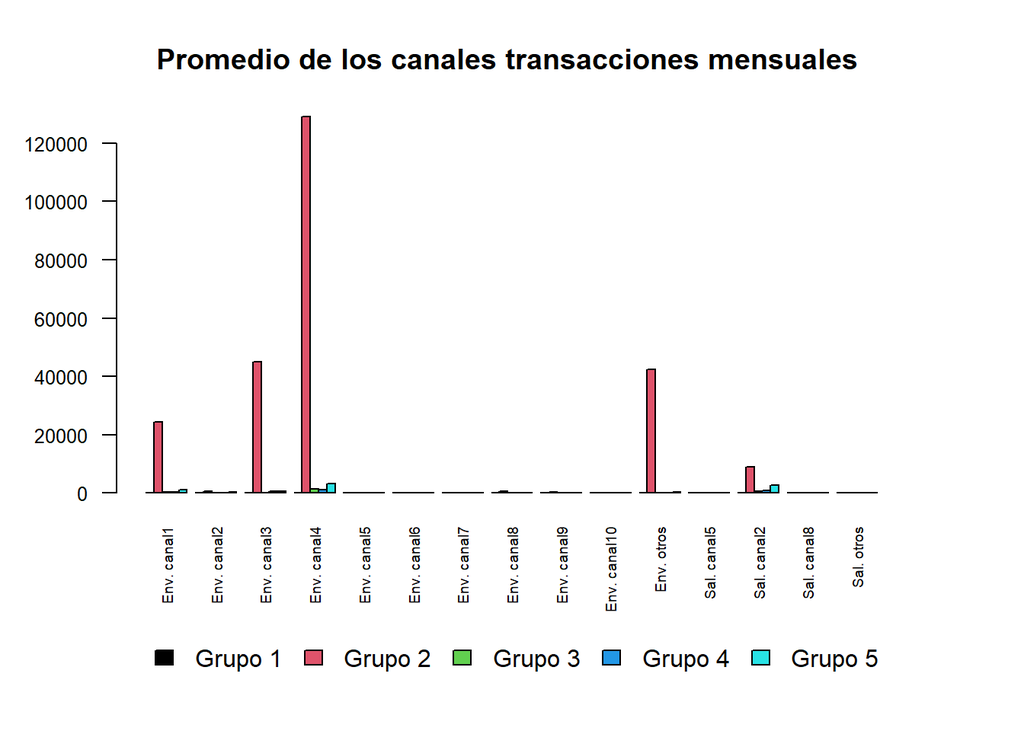

### Total de los canales transacciones mensuales

Para el total mensual del movimiento de los canales, de nuevo el grupo numero 2 supera en promedio a los demás grupos, en este caso se muestra que el canal numero 4 es el más usado durante los meses de un año, los grupos parecen tener una similitud entre los otros grupos en cada canal.

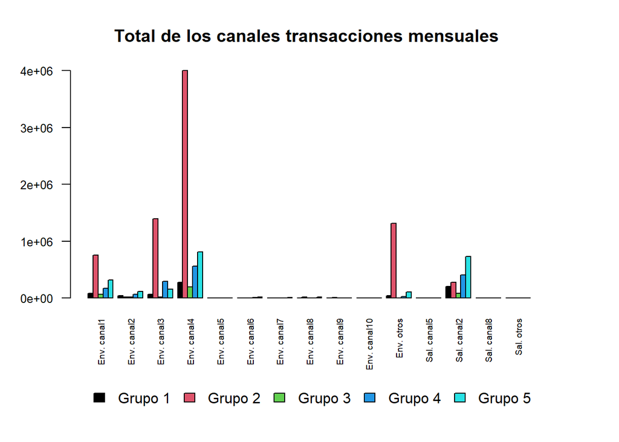

### Promedios Cuentas por cobrar (cxp) y Cuentas por pagar (cxc)

Las cuentas por cobrar son aquellas en donde el valor de un servicio se paga tiempo después de haber sido consumido, estos valores son ingresos que se le deben a la empresa. Por el contrario, las cuentas por pagar son valores que cada empresa debe por el consumo de un determinado servicio.

En los escenarios ideales las cuentas por pagar no deben exceder las cuentas por cobrar, por suerte, en el promedio de cxc y cxp para las empresas de los grupos seleccionados no sucede esto, sin embargo, para el grupo numero 2 las cuentas por pagar casi alcanzan las cuentas por cobrar lo que puede ser una alerta a este tipo de empresas.

Rotación de cxc y cxp

La rotación de este tipo de cuentas es un factor importante para la predicción de cuentas totales, indican el cambio de los ingresos y gastos generados, de esta forma una baja rotación en las cuentas por cobrar respecto a las cuentas por pagar sugiere que los gastos deben ser deudas a amplios plazos y que los ingresos generados están tardando en llegar respecto a los pagos de las cuentas por pagar. Este es el caso del grupo número 2.

tomado de [cxc y cxp3](https://repositorio.sena.edu.co/handle/11404/3163)

### Promedio total inventario y rotación de inventarios

La rotación de inventario es importante para las empresas pues indica que tanto se están vendiendo los productos o servicios ofrecidos respecto al total de la producción, una rotación de inventario baja puede afectar las empresas generando gastos de almacenamiento o perdida del valor de la mercancía. En este caso el grupo numero 3 es quien mayor flujo de inventario tiene en promedio y en comparación con los demás grupos, puede indicar que las empresas de este grupo realizan ventas de forma más frecuente que los demás grupos. Por otro lado, el grupo numero 1 muestra un promedio mayor en la rotación del inventario que en el promedio del total del inventario, de esta forma las empresas del grupo 1 son empresas que no tienen acumulación de inventario, pueden ser empresas en las que el servicio se genera luego de haber sido comprado (por ejemplo, empresas contratistas).

[rotacion inventario](https://repositorio.ucv.edu.pe/bitstream/handle/20.500.12692/30149/Campos_ASM.pdf?sequence=4&isAllowed=y)

### Promedio ciclo de negocio y ciclo financiero

En estos ciclos se busca identificar el tiempo que tardará la empresa en recuperar la inversión de su materia prima, así, un ciclo de negocio bueno tendrá valores menores en términos de tiempo en comparación a un ciclo de negocio malo.

tomado de [ciclo financiero](https://psicologiaymente.com/organizaciones/ciclo-financiero-empresa) tomado de [ciclo de negocio](https://efxto.com/diccionario/ciclo-de-negocio)

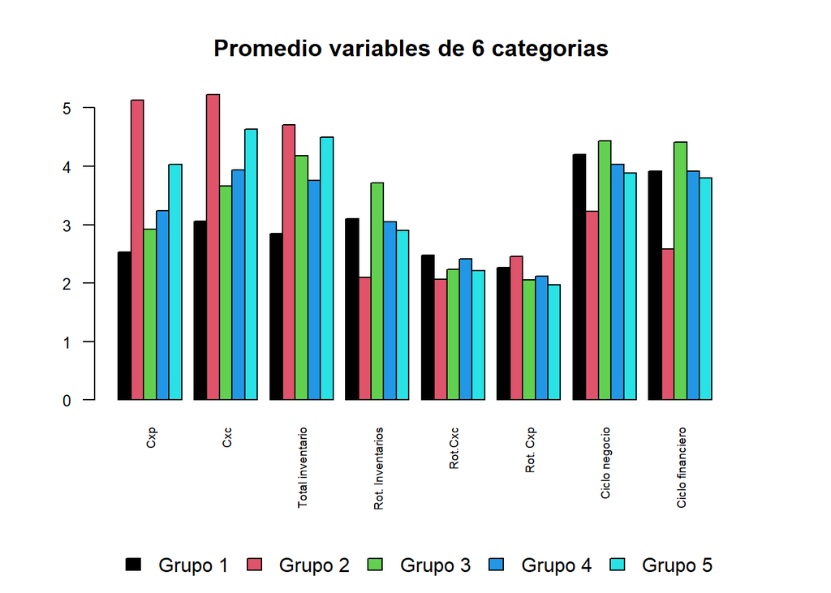

### Promedio Importaciones y Exportaciones

Los grupos 4 y 5 en este caso llevan la delantera en comparación a los demás grupos tanto en importaciones como en exportaciones, puede ser una de las razones por las cuales se destacan en entre los grupos con más movimiento en el total de los canales, las empresas que realizan más importaciones y exportaciones pueden ser empresas que tienen negocios con otras firmas parecidas a la empresa en cuestión, además, puede tener variaciones en sus flujos de caja y cuenta debido a los cambios de moneda e impuestos de los países en los que realiza el intercambio de mercancía.

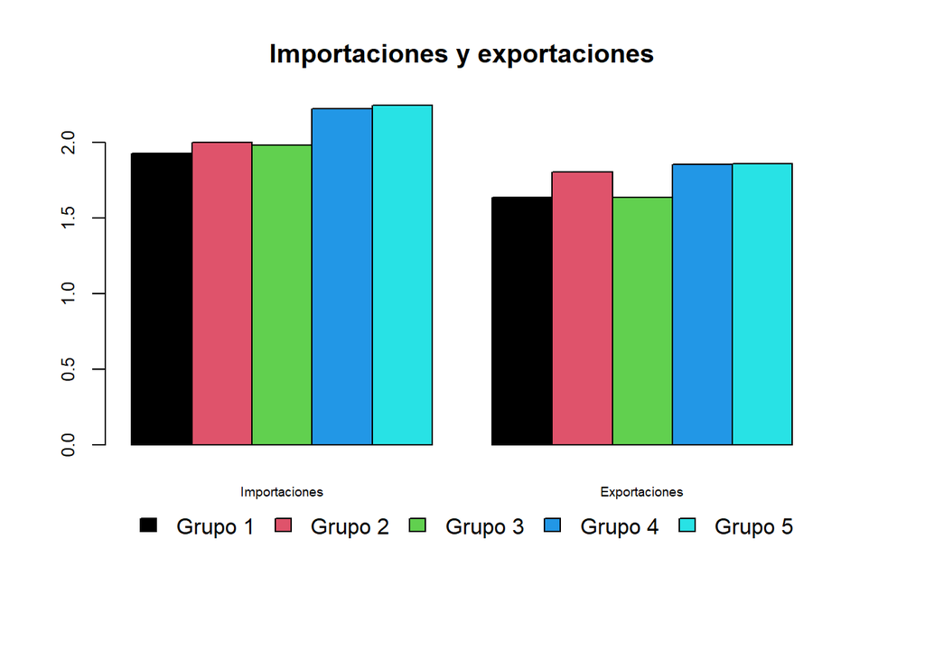

### Ventas físicas y electrónicas

En la actualidad tener ventas manejar campos de venta tanto físicos como electrónicos es una ventaja para cualquier empresa, esto se puede ver en los grupos que más han destacado durante todo el análisis y sobresale como una de las razones por las cuales algunas empresas no generan tanto movimiento por algunos canales como las empresas del grupo 1, son empresas que no parecen tener experiencia en campos electrónicos. Las empresas del grupo 1 al ser la mayoría de las muestras y tener un bajo nivel de ventas electrónicas sugiere que son empresas pequeñas

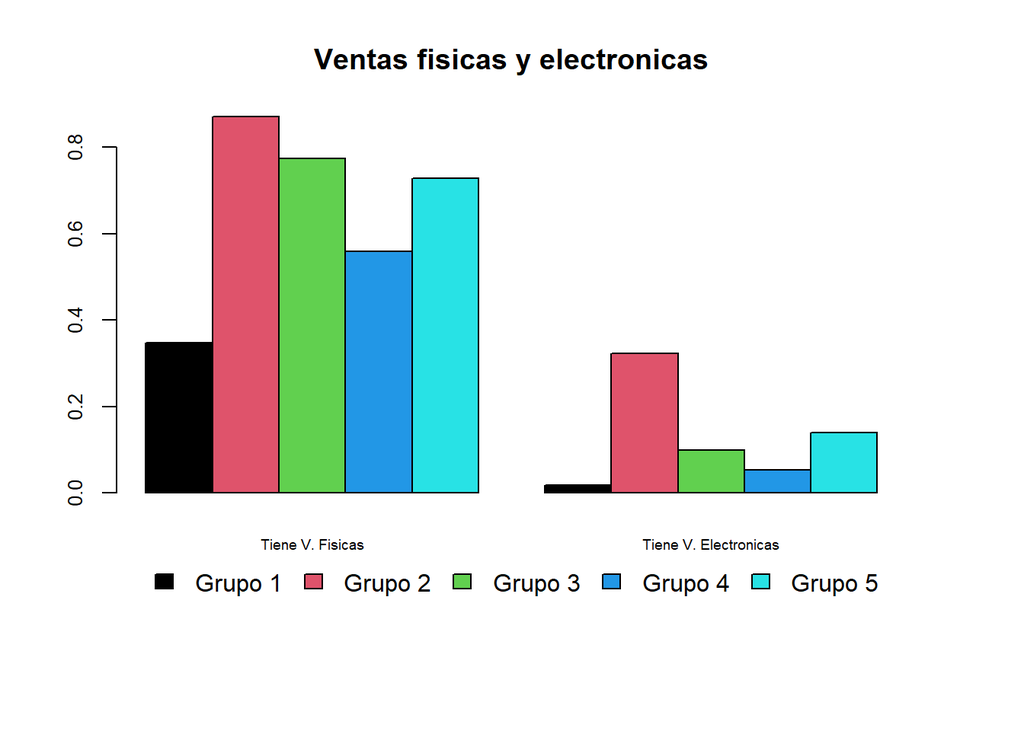

### Total recaudos personas jurídicas y naturales

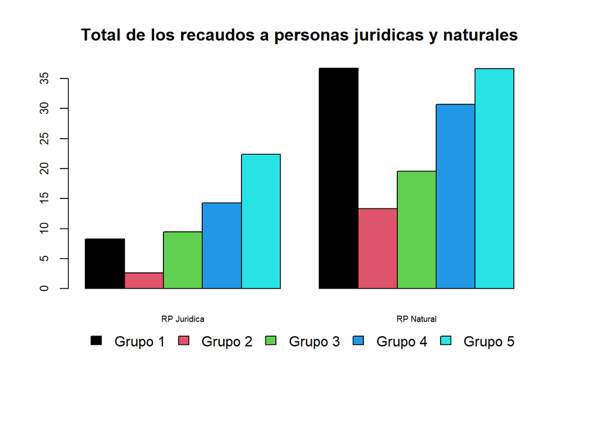

### Total de los pagos a personas jurídicas y naturales

En este caso, las empresas del grupo 1 realizan la mayoría de sus pagos a personas jurídicas, puede indicar que son empresas que generan servicios a personas naturales, con recursos o materias primas de personas jurídicas. En este punto puede verse como el grupo 4 tiene interacción con ambos tipos personas de forma proporcional lo que lo diferencia del grupo 5.

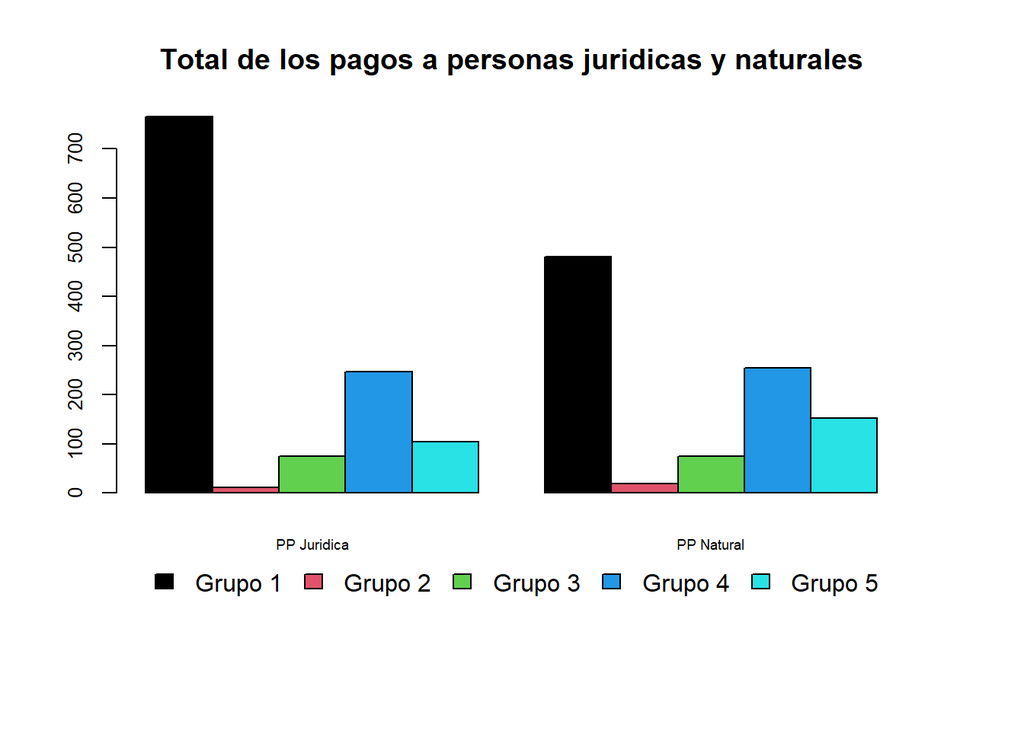

## Por ultimo… ¿Quiénes son estos grupos?

Con el fin de generar una clasificación agradable y no jerárquica a los grupos encontrados, y permitir al usuario de los grupos generar estrategias de mercado, damos nombre a los diferentes grupos de tal forma que cada empresa en el grupo se sienta cómoda con su clasificación evitando comparaciones de nivel entre los grupos.

Ademas, se disponen los enlaces de descarga de los archivos .csv para que el usuario final trabaje sobre estos

Clásicos

Nombrados así por ser representados por el 57% de los datos, son clientes que generan poco movimiento en los canales de entrada y salida, reciben sus ingresos de personas naturales, con servicios de personas jurídicas, su rotación de inventarios y cuentas por pagar y cobrar se mantiene estable en niveles indicados. Los clientes de este grupo deben generar gran interés en la compañía por ser la mayoría de sus clientes. Una estrategia publicitaria a este grupo puede llevar a fidelizar a estos clientes y llevarlos aumentar el movimiento a través de los distintos canales.

[clasicos.csv](https://drive.google.com/file/d/1c6SlZtK9JjfaeFNwoXakN27IsXXOWizQ/view?usp=sharing)

Viejos aliados

[Viejos_aliados.csv](https://drive.google.com/file/d/1bp-8_h20nx_AFCRRB1KPgvyUXqTm-nIE/view?usp=sharing)

Productores de la vieja escuela

[Productores_vieja_escuela.csv](https://drive.google.com/file/d/1C1LvPsCcVW82FXGcdx7ls6zoSCsiQDjc/view?usp=sharing)

Aventureros

Es el segundo grupo mas grande con 502 empresas cliente, y también es el segundo que mas realiza importaciones y exportaciones su nombre de aventureros es debido a su característica de interacción con otros países, es el tercer grupo que mas interacción genera en los canales de entrada y salida, curiosamente es uno de los que menor promedio de ventas electrónicas y menor promedio de inventario total.

[Aventureros.csv](https://drive.google.com/file/d/14LzQI5lkn-W2IzQIhSEyccvJivGtCXPT/view?usp=sharing)

Trotamundos

Después del grupo “Viejos aliados” es el segundo grupo que más movimiento genera a través de los canales de entrada y salida, es el grupo que más exportaciones e importaciones realiza en promedio en comparación con los demás grupos, sobresale por su inventario robusto y su manejo de ventas electrónicas.

[Trotamundos.csv](https://drive.google.com/file/d/1nHq2EAQDP_lPRf_1P6b5jW05vw1sppBT/view?usp=sharing)

[iconos png](https://www.freepik.com) y [iconos png](https://www.flaticon.es)